# Introduction to the scFeatureFilter package

Angeles Arzalluz-Luque, Guillaume Devailly, Anna Mantsoki, Anagha Joshi

2017-10-10

# 1 Preamble

## 1.1 Package aim

One of the steps in single cell RNA-seq analysis is the filtering of features (i.e. genes or transcripts) to retain only the most expressed ones. This allows to focus on features less affected by technical variations (relatively), and often increases the statistical power of the subsequent analyses.

This step is usually done by applying one or more arbitrary thresholds (i.e. mean TPM > 1, retention of features frequently detected across cells, etc.), or by using the data from spike-in RNA. This package aims to help the threshold decision, especially when spike-in controls are not available.

## 1.2 Method summary

Highly expressed features are less affected by technical variability than lowly expressed ones, and thus capture biological information more successfully. We propose to use highly expressed features as a reference to to estimate the drowning of biological variation in bins of features of decreasing expression. In this scenario, it is expected that features from major transcription programs will be correlated with each other across bins, unless the technical variation component dominates the expression results.

One of the package’s first steps is to select this reference bin of features (or ‘top window’ of features). We propose to use the 100 features with the highest mean expression across cells, and a reasonably low fraction of drop-outs (zero-expression values) as reference. Using more features will increase the noise in the biological variation reflected in this reference bin (as well as increase computation time), while using less features might result in insufficient capture of the biological complexity of the samples. Subsequent bins of features of decreasing mean expression across cells are then defined (by default, 1000 features per bin). Note that the size of the subsequent feature bins matters less than the size of the reference bin.

For comparison, several negative control bins are defined by randomly shuffling values of the top bin expression matrix, building a window that is expected to be completely uncorrelated. Then, every feature in each bin is correlated to every feature in the reference bin and the control bins to obtain correlation coefficient distributions. Ultimately, the variation of the distributions of correlation coefficients can be used to inform the threshold decision.

## 1.3 Installation

The development version of `scFeatureFilter` can be installed from GitHub using `devtools`:

```r
devtools::install_github("gdevailly/scFeatureFilter")
```

Once installed, the package is ready to be loaded:

```r
library(scFeatureFilter)

library(ggplot2)
library(cowplot) # multipanel figures + nice theme
```

# 2 Integrated usage

A single-function call option is available to the user, in which the entire package functionality is executed. This will filter the expression matrix and keep only the most informative highly expressed features, using default options:

```r
# example dataset included with the package:
scData_hESC
```

```
## # A tibble: 60,468 x 33
##           tracking_id GSM922224_hESCpassage0_Cell4_0
##                 <chr>                          <dbl>
##  1 ENSG00000000003.13                      55.332000
##  2  ENSG00000000005.5                       0.000000
##  3 ENSG00000000419.11                      53.974500
##  4 ENSG00000000457.12                       0.923849
##  5 ENSG00000000460.15                       7.078980
##  6 ENSG00000000938.11                       0.000000
##  7 ENSG00000000971.14                       0.000000
##  8 ENSG00000001036.12                       7.882880
##  9  ENSG00000001084.9                      21.156300
## 10 ENSG00000001167.13                       3.591210
## # ... with 60,458 more rows, and 31 more variables:
## #   GSM922225_hESCpassage0_Cell5_0 <dbl>,
## #   GSM922226_hESCpassage0_Cell6_0 <dbl>,
## #   GSM922227_hESCpassage0_Cell7_0 <dbl>,
## #   GSM922228_hESCpassage0_Cell8_0 <dbl>,
## #   GSM922230_hESCpassage0_Cell10_0 <dbl>,
## #   GSM922250_hESCpassage10_Cell1_0 <dbl>,
## #   GSM922251_hESCpassage10_Cell2_0 <dbl>,
## #   GSM922252_hESCpassage10_Cell3_0 <dbl>,
## #   GSM922253_hESCpassage10_Cell4_0 <dbl>,
## #   GSM922254_hESCpassage10_Cell5_0 <dbl>,
## #   GSM922255_hESCpassage10_Cell6_0 <dbl>,
## #   GSM922256_hESCpassage10_Cell7_0 <dbl>,
## #   GSM922257_hESCpassage10_Cell8_0 <dbl>,
## #   GSM922258_hESCpassage10_Cell9_0 <dbl>,
## #   GSM922259_hESCpassage10_Cell10_0 <dbl>,
## #   GSM922260_hESCpassage10_Cell11_0 <dbl>,
## #   GSM922261_hESCpassage10_Cell12_0 <dbl>,
## #   GSM922262_hESCpassage10_Cell13_0 <dbl>,
## #   GSM922263_hESCpassage10_Cell14_0 <dbl>,
## #   GSM922264_hESCpassage10_Cell15_0 <dbl>,
## #   GSM922265_hESCpassage10_Cell16_0 <dbl>,
## #   GSM922266_hESCpassage10_Cell17_0 <dbl>,
## #   GSM922267_hESCpassage10_Cell18_0 <dbl>,
## #   GSM922268_hESCpassage10_Cell19_0 <dbl>,
## #   GSM922269_hESCpassage10_Cell20_0 <dbl>,
## #   GSM922270_hESCpassage10_Cell21_0 <dbl>,
## #   GSM922271_hESCpassage10_Cell22_0 <dbl>,
## #   GSM922272_hESCpassage10_Cell23_0 <dbl>,
## #   GSM922273_hESCpassage10_Cell24_0 <dbl>,
## #   GSM922274_hESCpassage10_Cell25_0 <dbl>,
## #   GSM922275_hESCpassage10_Cell26_0 <dbl>
```

```r
# filtering of the dataset with a single function call:
sc_feature_filter(scData_hESC)
## Mean expression of last top gene: 2114.40221875
## Number of windows: 18
## # A tibble: 7,442 x 33
##             geneName GSM922224_hESCpassage0_Cell4_0
##                <chr>                          <dbl>
##  1 ENSG00000228253.1                       40272.50
##  2 ENSG00000198888.2                       30747.10
##  3 ENSG00000198712.1                       11056.80
##  4 ENSG00000211459.2                       17099.70
##  5 ENSG00000212907.2                       19984.90
##  6 ENSG00000198899.2                       11289.60
##  7 ENSG00000198727.2                        7005.42
##  8 ENSG00000210082.2                       17238.80
##  9 ENSG00000198886.2                       14995.40
## 10 ENSG00000198938.2                        9675.66
## # ... with 7,432 more rows, and 31 more variables:
## #   GSM922225_hESCpassage0_Cell5_0 <dbl>,
## #   GSM922226_hESCpassage0_Cell6_0 <dbl>,
## #   GSM922227_hESCpassage0_Cell7_0 <dbl>,
## #   GSM922228_hESCpassage0_Cell8_0 <dbl>,
## #   GSM922230_hESCpassage0_Cell10_0 <dbl>,
## #   GSM922250_hESCpassage10_Cell1_0 <dbl>,
## #   GSM922251_hESCpassage10_Cell2_0 <dbl>,
## #   GSM922252_hESCpassage10_Cell3_0 <dbl>,
## #   GSM922253_hESCpassage10_Cell4_0 <dbl>,
## #   GSM922254_hESCpassage10_Cell5_0 <dbl>,
## #   GSM922255_hESCpassage10_Cell6_0 <dbl>,
## #   GSM922256_hESCpassage10_Cell7_0 <dbl>,
## #   GSM922257_hESCpassage10_Cell8_0 <dbl>,
## #   GSM922258_hESCpassage10_Cell9_0 <dbl>,
## #   GSM922259_hESCpassage10_Cell10_0 <dbl>,
## #   GSM922260_hESCpassage10_Cell11_0 <dbl>,
## #   GSM922261_hESCpassage10_Cell12_0 <dbl>,
## #   GSM922262_hESCpassage10_Cell13_0 <dbl>,
## #   GSM922263_hESCpassage10_Cell14_0 <dbl>,
## #   GSM922264_hESCpassage10_Cell15_0 <dbl>,
## #   GSM922265_hESCpassage10_Cell16_0 <dbl>,
## #   GSM922266_hESCpassage10_Cell17_0 <dbl>,
## #   GSM922267_hESCpassage10_Cell18_0 <dbl>,
## #   GSM922268_hESCpassage10_Cell19_0 <dbl>,
## #   GSM922269_hESCpassage10_Cell20_0 <dbl>,
## #   GSM922270_hESCpassage10_Cell21_0 <dbl>,
## #   GSM922271_hESCpassage10_Cell22_0 <dbl>,
## #   GSM922272_hESCpassage10_Cell23_0 <dbl>,
## #   GSM922273_hESCpassage10_Cell24_0 <dbl>,
## #   GSM922274_hESCpassage10_Cell25_0 <dbl>,
## #   GSM922275_hESCpassage10_Cell26_0 <dbl>
```

# 3 Detailed usage

## 3.1 Loading data

*scFeatureFilter* uses an expression matrix (either as a `matrix`, a `data.frame`, a `tibble` or a `SingleCellExperiment` R object) as input. Support of Bioconductor’s expression set objects will arrive shortly. Note that features should be in rows, while cells should be in columns.

We recommend providing normalized expression values where at least library size is accounted for, such as TPM or FPKM, rather than raw counts.

An example dataset is supplied with the package:

```r
scData_hESC
```

```
## # A tibble: 60,468 x 33
##           tracking_id GSM922224_hESCpassage0_Cell4_0
##                 <chr>                          <dbl>
##  1 ENSG00000000003.13                      55.332000
##  2  ENSG00000000005.5                       0.000000
##  3 ENSG00000000419.11                      53.974500
##  4 ENSG00000000457.12                       0.923849
##  5 ENSG00000000460.15                       7.078980
##  6 ENSG00000000938.11                       0.000000
##  7 ENSG00000000971.14                       0.000000
##  8 ENSG00000001036.12                       7.882880
##  9  ENSG00000001084.9                      21.156300
## 10 ENSG00000001167.13                       3.591210
## # ... with 60,458 more rows, and 31 more variables:
## #   GSM922225_hESCpassage0_Cell5_0 <dbl>,
## #   GSM922226_hESCpassage0_Cell6_0 <dbl>,
## #   GSM922227_hESCpassage0_Cell7_0 <dbl>,
## #   GSM922228_hESCpassage0_Cell8_0 <dbl>,
## #   GSM922230_hESCpassage0_Cell10_0 <dbl>,
## #   GSM922250_hESCpassage10_Cell1_0 <dbl>,
## #   GSM922251_hESCpassage10_Cell2_0 <dbl>,
## #   GSM922252_hESCpassage10_Cell3_0 <dbl>,
## #   GSM922253_hESCpassage10_Cell4_0 <dbl>,
## #   GSM922254_hESCpassage10_Cell5_0 <dbl>,
## #   GSM922255_hESCpassage10_Cell6_0 <dbl>,
## #   GSM922256_hESCpassage10_Cell7_0 <dbl>,
## #   GSM922257_hESCpassage10_Cell8_0 <dbl>,
## #   GSM922258_hESCpassage10_Cell9_0 <dbl>,
## #   GSM922259_hESCpassage10_Cell10_0 <dbl>,
## #   GSM922260_hESCpassage10_Cell11_0 <dbl>,
## #   GSM922261_hESCpassage10_Cell12_0 <dbl>,
## #   GSM922262_hESCpassage10_Cell13_0 <dbl>,
## #   GSM922263_hESCpassage10_Cell14_0 <dbl>,
## #   GSM922264_hESCpassage10_Cell15_0 <dbl>,
## #   GSM922265_hESCpassage10_Cell16_0 <dbl>,
## #   GSM922266_hESCpassage10_Cell17_0 <dbl>,
## #   GSM922267_hESCpassage10_Cell18_0 <dbl>,
## #   GSM922268_hESCpassage10_Cell19_0 <dbl>,
## #   GSM922269_hESCpassage10_Cell20_0 <dbl>,
## #   GSM922270_hESCpassage10_Cell21_0 <dbl>,
## #   GSM922271_hESCpassage10_Cell22_0 <dbl>,
## #   GSM922272_hESCpassage10_Cell23_0 <dbl>,
## #   GSM922273_hESCpassage10_Cell24_0 <dbl>,
## #   GSM922274_hESCpassage10_Cell25_0 <dbl>,
## #   GSM922275_hESCpassage10_Cell26_0 <dbl>
```

*The example dataset was processed by [Mantsoki et al. (2016)](https://www.ncbi.nlm.nih.gov/pubmed/26951854), data from human Embryonic Stem cells was generated by [Yan et al. (2013)](https://www.ncbi.nlm.nih.gov/pubmed/23934149).*

## 3.2 Binning data

Firstly, a mean expression and a coefficient of variation column is added to the expression matrix provided using the `calculate_cvs` function:

```r
calculate_cvs(scData_hESC)
```

```
## # A tibble: 17,929 x 36
##              geneName      mean        sd        cv
##                 <chr>     <dbl>     <dbl>     <dbl>
##  1 ENSG00000000003.13 70.022328 73.332127 1.0472678
##  2  ENSG00000000005.5  1.000291  2.527535 2.5267987
##  3 ENSG00000000419.11 80.991847 71.534922 0.8832361
##  4 ENSG00000000457.12  1.590995  1.804686 1.1343132
##  5 ENSG00000000460.15  9.531320  8.444314 0.8859543
##  6 ENSG00000001036.12 21.719122 16.969845 0.7813320
##  7  ENSG00000001084.9 17.991673 15.616758 0.8679992
##  8 ENSG00000001167.13  4.106190  6.644126 1.6180755
##  9 ENSG00000001460.16  7.222735 17.157835 2.3755317
## 10 ENSG00000001461.15  4.942530  7.396355 1.4964715
## # ... with 17,919 more rows, and 32 more variables:
## #   GSM922224_hESCpassage0_Cell4_0 <dbl>,
## #   GSM922225_hESCpassage0_Cell5_0 <dbl>,
## #   GSM922226_hESCpassage0_Cell6_0 <dbl>,
## #   GSM922227_hESCpassage0_Cell7_0 <dbl>,
## #   GSM922228_hESCpassage0_Cell8_0 <dbl>,
## #   GSM922230_hESCpassage0_Cell10_0 <dbl>,
## #   GSM922250_hESCpassage10_Cell1_0 <dbl>,
## #   GSM922251_hESCpassage10_Cell2_0 <dbl>,
## #   GSM922252_hESCpassage10_Cell3_0 <dbl>,
## #   GSM922253_hESCpassage10_Cell4_0 <dbl>,
## #   GSM922254_hESCpassage10_Cell5_0 <dbl>,
## #   GSM922255_hESCpassage10_Cell6_0 <dbl>,
## #   GSM922256_hESCpassage10_Cell7_0 <dbl>,
## #   GSM922257_hESCpassage10_Cell8_0 <dbl>,
## #   GSM922258_hESCpassage10_Cell9_0 <dbl>,
## #   GSM922259_hESCpassage10_Cell10_0 <dbl>,
## #   GSM922260_hESCpassage10_Cell11_0 <dbl>,
## #   GSM922261_hESCpassage10_Cell12_0 <dbl>,
## #   GSM922262_hESCpassage10_Cell13_0 <dbl>,
## #   GSM922263_hESCpassage10_Cell14_0 <dbl>,
## #   GSM922264_hESCpassage10_Cell15_0 <dbl>,
## #   GSM922265_hESCpassage10_Cell16_0 <dbl>,
## #   GSM922266_hESCpassage10_Cell17_0 <dbl>,
## #   GSM922267_hESCpassage10_Cell18_0 <dbl>,
## #   GSM922268_hESCpassage10_Cell19_0 <dbl>,
## #   GSM922269_hESCpassage10_Cell20_0 <dbl>,
## #   GSM922270_hESCpassage10_Cell21_0 <dbl>,
## #   GSM922271_hESCpassage10_Cell22_0 <dbl>,
## #   GSM922272_hESCpassage10_Cell23_0 <dbl>,
## #   GSM922273_hESCpassage10_Cell24_0 <dbl>,
## #   GSM922274_hESCpassage10_Cell25_0 <dbl>,
## #   GSM922275_hESCpassage10_Cell26_0 <dbl>
```

We can explore the mean - variance relationship of the dataset with the `plot_mean_variance` function:

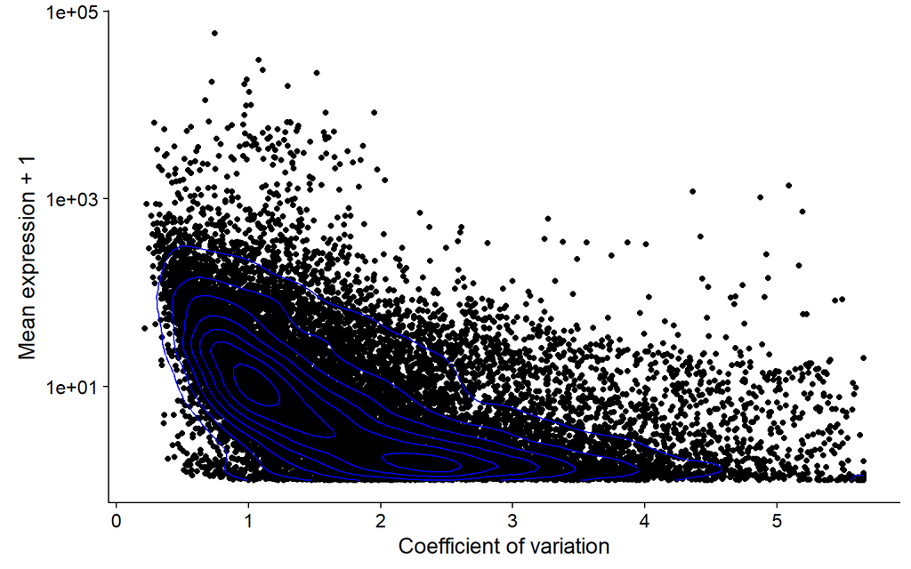

```r
library(magrittr) # to use the pipe %>%

calculate_cvs(scData_hESC) %>%
    plot_mean_variance(colourByBin = FALSE)
```

The top window (or reference bin) is then defined with the `define_top_genes` function, while the rest of bins are created with the `bin_scdata` function:

```r
scData_hESC %>%
    calculate_cvs %>%
    define_top_genes(window_size = 100) %>%
    bin_scdata(window_size = 1000)
## Mean expression of last top gene: 2114.40221875
## Number of windows: 18
## # A tibble: 17,929 x 37
##             geneName     mean       sd        cv   bin
##                <chr>    <dbl>    <dbl>     <dbl> <dbl>
##  1 ENSG00000228253.1 58449.71 43459.80 0.7435418     1
##  2 ENSG00000198888.2 30454.17 32770.73 1.0760669     1
##  3 ENSG00000198712.1 23484.34 26032.12 1.1084885     1
##  4 ENSG00000211459.2 21988.64 33333.64 1.5159481     1
##  5 ENSG00000212907.2 18748.69 18500.55 0.9867646     1
##  6 ENSG00000198899.2 17556.83 12659.94 0.7210835     1
##  7 ENSG00000198727.2 16748.35 16227.66 0.9689110     1
##  8 ENSG00000210082.2 16013.17 20764.97 1.2967434     1
##  9 ENSG00000198886.2 13890.04 13973.37 1.0059990     1
## 10 ENSG00000198938.2 11299.42  7602.17 0.6727927     1
## # ... with 17,919 more rows, and 32 more variables:
## #   GSM922224_hESCpassage0_Cell4_0 <dbl>,
## #   GSM922225_hESCpassage0_Cell5_0 <dbl>,
## #   GSM922226_hESCpassage0_Cell6_0 <dbl>,
## #   GSM922227_hESCpassage0_Cell7_0 <dbl>,
## #   GSM922228_hESCpassage0_Cell8_0 <dbl>,
## #   GSM922230_hESCpassage0_Cell10_0 <dbl>,
## #   GSM922250_hESCpassage10_Cell1_0 <dbl>,
## #   GSM922251_hESCpassage10_Cell2_0 <dbl>,
## #   GSM922252_hESCpassage10_Cell3_0 <dbl>,
## #   GSM922253_hESCpassage10_Cell4_0 <dbl>,
## #   GSM922254_hESCpassage10_Cell5_0 <dbl>,
## #   GSM922255_hESCpassage10_Cell6_0 <dbl>,
## #   GSM922256_hESCpassage10_Cell7_0 <dbl>,
## #   GSM922257_hESCpassage10_Cell8_0 <dbl>,
## #   GSM922258_hESCpassage10_Cell9_0 <dbl>,
## #   GSM922259_hESCpassage10_Cell10_0 <dbl>,
## #   GSM922260_hESCpassage10_Cell11_0 <dbl>,
## #   GSM922261_hESCpassage10_Cell12_0 <dbl>,
## #   GSM922262_hESCpassage10_Cell13_0 <dbl>,
## #   GSM922263_hESCpassage10_Cell14_0 <dbl>,
## #   GSM922264_hESCpassage10_Cell15_0 <dbl>,
## #   GSM922265_hESCpassage10_Cell16_0 <dbl>,
## #   GSM922266_hESCpassage10_Cell17_0 <dbl>,
## #   GSM922267_hESCpassage10_Cell18_0 <dbl>,
## #   GSM922268_hESCpassage10_Cell19_0 <dbl>,
## #   GSM922269_hESCpassage10_Cell20_0 <dbl>,
## #   GSM922270_hESCpassage10_Cell21_0 <dbl>,
## #   GSM922271_hESCpassage10_Cell22_0 <dbl>,
## #   GSM922272_hESCpassage10_Cell23_0 <dbl>,
## #   GSM922273_hESCpassage10_Cell24_0 <dbl>,
## #   GSM922274_hESCpassage10_Cell25_0 <dbl>,
## #   GSM922275_hESCpassage10_Cell26_0 <dbl>
```

Then, we can plot the resulting bin definition using the same `plot_mean_variance` function, setting the `colourByBin` argument to `TRUE`:

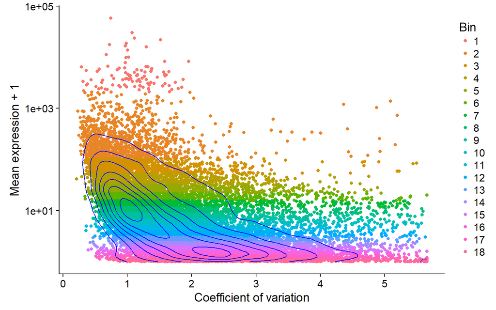

```r
myPlot <- scData_hESC %>%
    calculate_cvs %>%
    define_top_genes(window_size = 100) %>%
    bin_scdata(window_size = 1000) %>%
    plot_mean_variance(colourByBin = TRUE, density_color = "blue")
## Mean expression of last top gene: 2114.40221875
## Number of windows: 18

myPlot
```

Note that the plotting function outputs are `ggplot2` objects that can be further customized. See an example here:

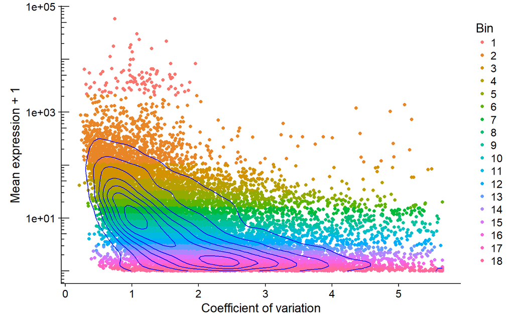

```r
myPlot + annotation_logticks(sides = "l")
```

## 3.3 Correlation of the bins

After binning the data, correlations can be calculated. Every feature in each window is correlated to every other feature in the reference bin (as well as in the randomized control bins) using the function `correlate_windows`:

```r
corDistrib <- scData_hESC %>%
    calculate_cvs %>%
    define_top_genes(window_size = 100) %>%
    bin_scdata(window_size = 1000) %>%
    correlate_windows(n_random = 3)
## Mean expression of last top gene: 2114.40221875
## Number of windows: 18
```

For visualization of the correlation values, probability distributions can be computed using and plotted using the `correlations_to_densities` and `plot_correlations_distributions` functions:

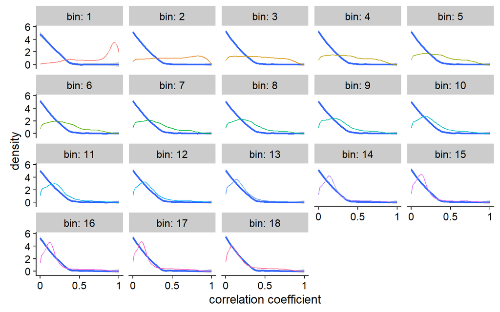

```r
corDens <- correlations_to_densities(corDistrib, absolute_cc = TRUE)
plot_correlations_distributions(corDens, facet_ncol = 5) +
    scale_x_continuous(breaks = c(0, 0.5, 1), labels = c("0", "0.5", "1"))
## `geom_smooth()` using method = 'loess'
```

The coloured lines indicate the correlation coefficient distributions for each bin compared to the reference bin (bin 1 shows the autocorrelation of the reference bin). The thicker blue lines with grey area (barely visible) represents the correlation coefficient distributions for each bin compared to the randomized control bins.

Notice that the correlation distributions shift from high to low values as the bin number increases, i.e. as the mean expression level of the features decreases, indicating a higher influence of technical variability in the expression results.

*Note: the `absolute_cc = TRUE` option, which is the default, instructs the package to work with the absolute value of the correlation coefficient. Therefore, highly negatively correlated features will count as highly correlated. Setting this option as `TRUE` also produces clearer plots, and reduces the emphasis on non-symmetrical, near 0, shifts of correlation values that are not interpretable.*

We can quantify the steady decrease of correlation values as feature expression goes down using the `get_mean_median` function, improving interpretability of the extent of technical variability in the data:

```r
metrics <- get_mean_median(corDistrib)
metrics
```

```
## # A tibble: 72 x 4
##      bin                window      mean    median
##    <dbl>                 <chr>     <dbl>     <dbl>
##  1     1 shuffled_top_window_1 0.1319378 0.1147424
##  2     1 shuffled_top_window_2 0.1248005 0.1107722
##  3     1 shuffled_top_window_3 0.1380571 0.1227756
##  4     1            top_window 0.7184050 0.8439585
##  5     2 shuffled_top_window_1 0.1314488 0.1078423
##  6     2 shuffled_top_window_2 0.1264610 0.1045008
##  7     2 shuffled_top_window_3 0.1337526 0.1110379
##  8     2            top_window 0.5136430 0.5279849
##  9     3 shuffled_top_window_1 0.1309884 0.1038174
## 10     3 shuffled_top_window_2 0.1274672 0.1021117
## # ... with 62 more rows
```

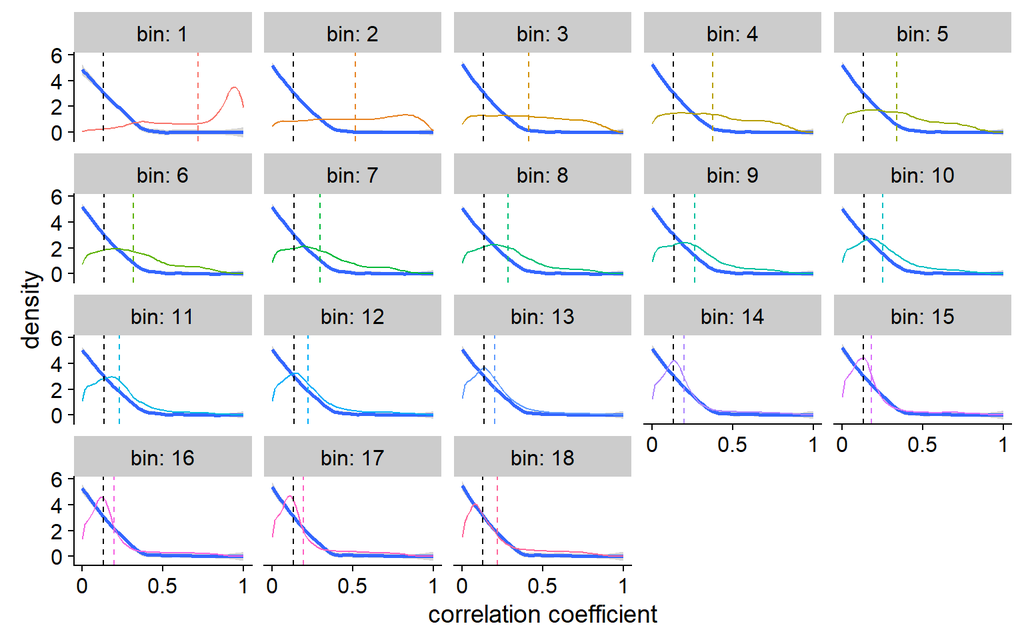

```r
plot_correlations_distributions(corDens, metrics = metrics, facet_ncol = 5) +
    scale_x_continuous(breaks = c(0, 0.5, 1), labels = c("0", "0.5", "1"))
## `geom_smooth()` using method = 'loess'
```

The added dashed lines are the mean values of the distributions. The `plot_metric` function focalized on these means of distributions:

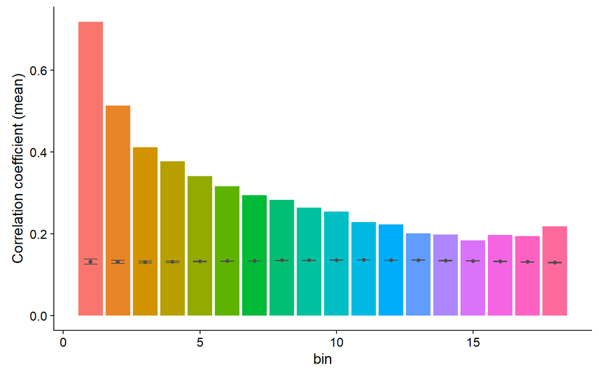

```r
plot_metric(metrics, show_ctrl = FALSE, show_threshold = FALSE)
```

## 3.4 Choosing a threshold

On the previous plot, a background reference can be added as a dashed line, by taking the mean value of the correlations of every bin to the randomized control bins:

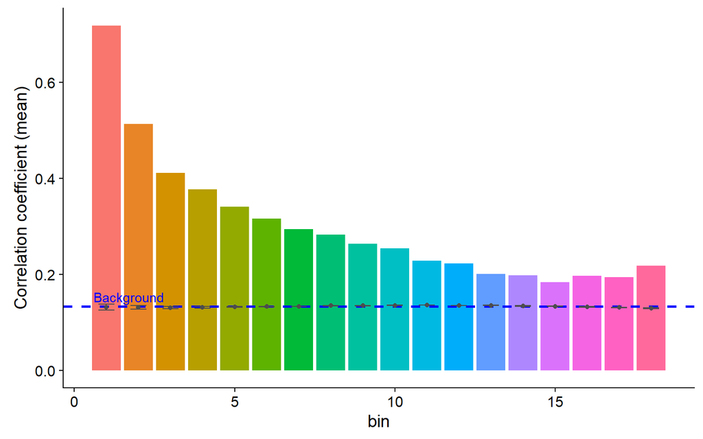

```r
plot_metric(metrics, show_ctrl = TRUE, show_threshold = FALSE)
```

Then, the user can decide to plot only bins for which the mean correlation value against the reference window is higher than, for example, twice the background:

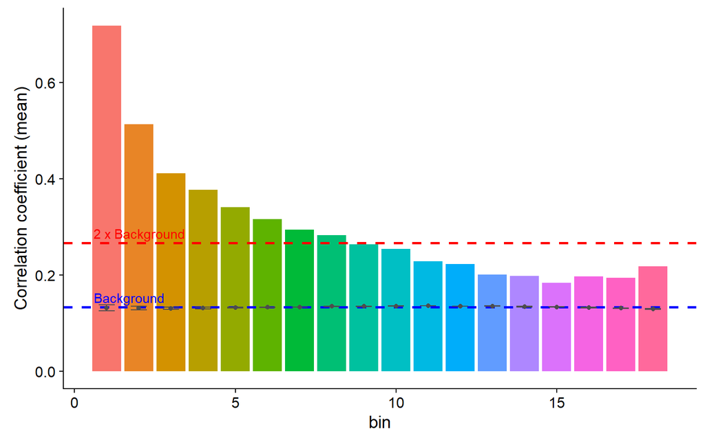

```r
plot_metric(metrics, show_ctrl = TRUE, show_threshold = TRUE, threshold = 2)
```

To further assist thresholding, the function `determine_bin_cutoff` will return the number of the first bin of features that falls below the set threshold:

```r
determine_bin_cutoff(metrics, threshold = 2)
```

```
## [1] 9
```

Finally, using this information, the function `filter_expression_table` can be used to obtain a filtered expression matrix from the original data:

```r
binned_data <- scData_hESC %>%
    calculate_cvs %>%
    define_top_genes(window_size = 100) %>%
    bin_scdata(window_size = 1000)
## Mean expression of last top gene: 2114.40221875
## Number of windows: 18
metrics <- correlate_windows(binned_data, n_random = 3) %>%
    get_mean_median

filtered_data <- filter_expression_table(
    binned_data,
    bin_cutoff = determine_bin_cutoff(metrics)
)

dim(scData_hESC)
```

```
## [1] 60468    33
```

```r
dim(filtered_data)
```

```
## [1] 7442   33
```

```r
filtered_data
```

```
## # A tibble: 7,442 x 33
##             geneName GSM922224_hESCpassage0_Cell4_0
##                <chr>                          <dbl>
##  1 ENSG00000228253.1                       40272.50
##  2 ENSG00000198888.2                       30747.10
##  3 ENSG00000198712.1                       11056.80
##  4 ENSG00000211459.2                       17099.70
##  5 ENSG00000212907.2                       19984.90
##  6 ENSG00000198899.2                       11289.60
##  7 ENSG00000198727.2                        7005.42
##  8 ENSG00000210082.2                       17238.80
##  9 ENSG00000198886.2                       14995.40
## 10 ENSG00000198938.2                        9675.66
## # ... with 7,432 more rows, and 31 more variables:
## #   GSM922225_hESCpassage0_Cell5_0 <dbl>,
## #   GSM922226_hESCpassage0_Cell6_0 <dbl>,
## #   GSM922227_hESCpassage0_Cell7_0 <dbl>,
## #   GSM922228_hESCpassage0_Cell8_0 <dbl>,
## #   GSM922230_hESCpassage0_Cell10_0 <dbl>,
## #   GSM922250_hESCpassage10_Cell1_0 <dbl>,
## #   GSM922251_hESCpassage10_Cell2_0 <dbl>,
## #   GSM922252_hESCpassage10_Cell3_0 <dbl>,
## #   GSM922253_hESCpassage10_Cell4_0 <dbl>,
## #   GSM922254_hESCpassage10_Cell5_0 <dbl>,
## #   GSM922255_hESCpassage10_Cell6_0 <dbl>,
## #   GSM922256_hESCpassage10_Cell7_0 <dbl>,
## #   GSM922257_hESCpassage10_Cell8_0 <dbl>,
## #   GSM922258_hESCpassage10_Cell9_0 <dbl>,
## #   GSM922259_hESCpassage10_Cell10_0 <dbl>,
## #   GSM922260_hESCpassage10_Cell11_0 <dbl>,
## #   GSM922261_hESCpassage10_Cell12_0 <dbl>,
## #   GSM922262_hESCpassage10_Cell13_0 <dbl>,
## #   GSM922263_hESCpassage10_Cell14_0 <dbl>,
## #   GSM922264_hESCpassage10_Cell15_0 <dbl>,
## #   GSM922265_hESCpassage10_Cell16_0 <dbl>,
## #   GSM922266_hESCpassage10_Cell17_0 <dbl>,
## #   GSM922267_hESCpassage10_Cell18_0 <dbl>,
## #   GSM922268_hESCpassage10_Cell19_0 <dbl>,
## #   GSM922269_hESCpassage10_Cell20_0 <dbl>,
## #   GSM922270_hESCpassage10_Cell21_0 <dbl>,
## #   GSM922271_hESCpassage10_Cell22_0 <dbl>,
## #   GSM922272_hESCpassage10_Cell23_0 <dbl>,
## #   GSM922273_hESCpassage10_Cell24_0 <dbl>,
## #   GSM922274_hESCpassage10_Cell25_0 <dbl>,
## #   GSM922275_hESCpassage10_Cell26_0 <dbl>
```

*Note: most of the features are filtered at the `calculate_cvs` step because hey have a too high fraction of drop-outs or zero-expression. The maximum fraction of 0 expression tolerated by scFeatureFilter is 75%, by default.*

## 3.5 Working with SingleCellExperiment objects

This package accpets `SingleCellExperiment` as inputs for `sc_feature_filter` and `calculate_cvs` functions. However, it does not retun such objects at the moment. One can retrieve a filtered `SingleCellExperiment` objects like this:

```r
library(SingleCellExperiment)
library(scRNAseq) # example datasets
data("allen")
sce_allen <- as(allen, "SingleCellExperiment")

# sce_allen is an SingleCellExperiment object
sce_allen
## class: SingleCellExperiment
## dim: 20908 379
## metadata(2): SuppInfo which_qc
## assays(4): tophat_counts cufflinks_fpkm rsem_counts rsem_tpm
## rownames(20908): 0610007P14Rik 0610009B22Rik ... Zzef1 Zzz3
## rowData names(0):
## colnames(379): SRR2140028 SRR2140022 ... SRR2139341 SRR2139336
## colData names(22): NREADS NALIGNED ... Animal.ID passes_qc_checks_s
## reducedDimNames(0):
## spikeNames(0):

filtered_allen <- sc_feature_filter(sce_allen, sce_assay = "rsem_tpm")
is.matrix(filtered_allen) # filtered_allen is a tibble
```

[output not shown]

```r
sce_filtered_allen <- sce_allen[rownames(filtered_allen), ]
sce_filtered_allen
## class: SingleCellExperiment
## dim: 2152 379
## metadata(2): SuppInfo which_qc
## assays(4): tophat_counts cufflinks_fpkm rsem_counts rsem_tpm
## rownames(2152): ERCC-00074 Ubb ... Papola Sri
## rowData names(0):
## colnames(379): SRR2140028 SRR2140022 ... SRR2139341 SRR2139336
## colData names(22): NREADS NALIGNED ... Animal.ID passes_qc_checks_s
## reducedDimNames(0):
## spikeNames(0):
```

# 4 Parameter values

Several parameters are used in `sc_feature_filter` or in step-by-step functions. Their default values are set using mouse an human data and should work for eukaryote species with multi-exonic genes (metazoans & plants).

## 4.1 `max_zeros`

The `max_zeros` parameter (default value `0.75`) is used as a first filter. Features with more than this proportion of cells with zero expression will be removed. Zero expression can reflect both an absence of expression in the cell of origin, or a drop-out event during the library preparation. This technical drop out can be quite high in scRNAseq protocols. More stringent values for this parameter could be `0.5` or `0.25`. As features with many zero-expression events are usually lowly expressed in other cells, this parameter will mostly impact the number of bins in the rest of the method, adding or removing lowly expressed bins of features.

## 4.2 `top_window_size`

The `top_window_size` parameter (default to `100`) can have significant impacts on the rest of the pipeline. It sets the number of feature with the highest mean expression that will be used as a reference bin. If the reference window is too small (i.e. `10`), it will not capture enough of the biological variation. On the contrary, a too large window (i.e. `2000`) might include to many features highly affected from technical variations to be of any use. We therefore suggest keeping it at `100` or near that value.

The function `plot_top_window_autocor` can be used to visualy explore the mean auto-correlation value of features in the top bin with themselves depending on the number of features in the top bin:

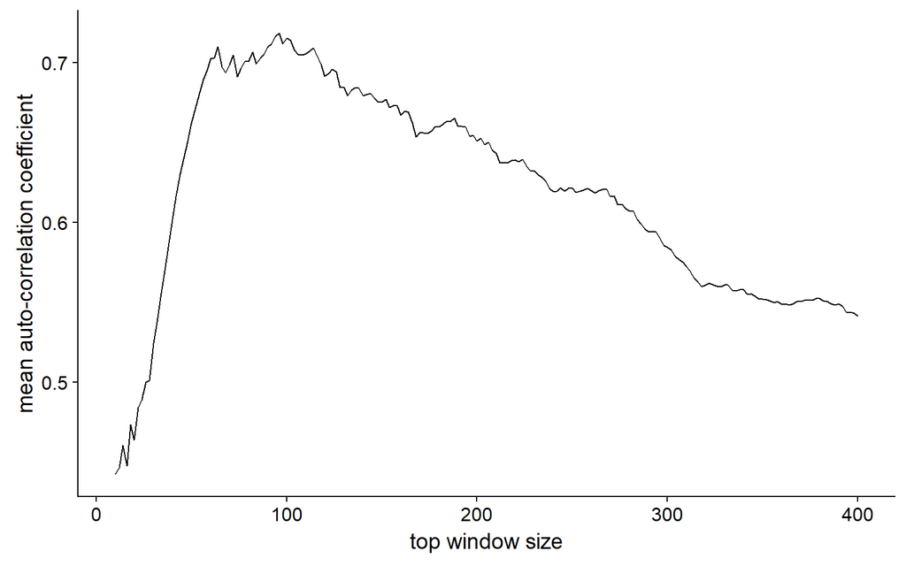

```r
plot_top_window_autocor(calculate_cvs(scData_hESC))
```

## 4.3 `other_window_size`

The `other_window_size` parameter (default to `1000`) is the number of features included in the other bins of feature. It can safely be decreased to `500` or `250`, which will result in more bins, without changing much the proposed filtering threshold:

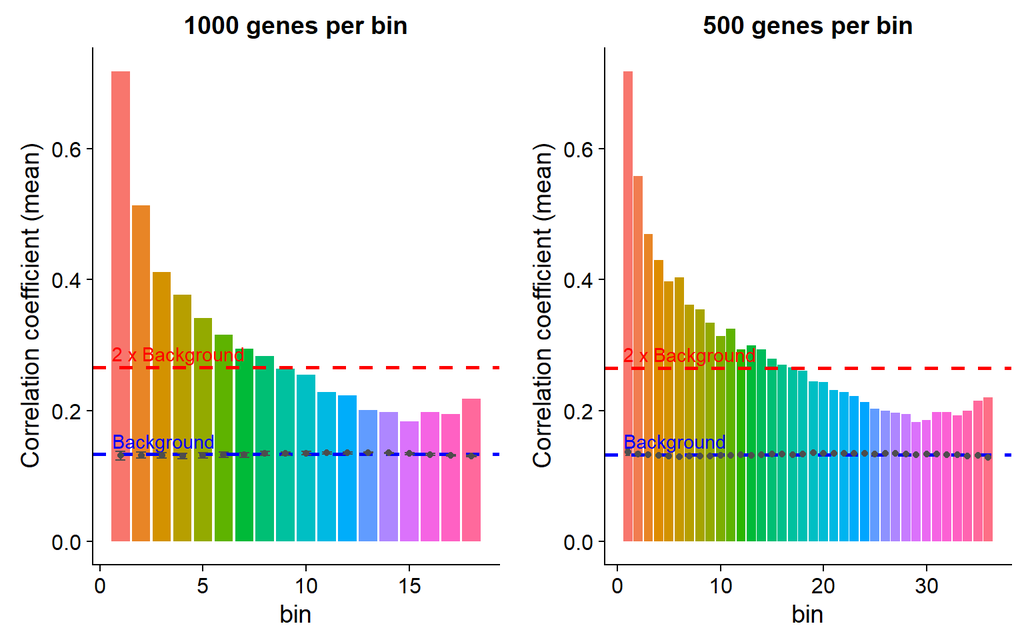

```r
metrics_bigBins <- scData_hESC %>%
    calculate_cvs %>%
    define_top_genes(window_size = 100) %>%
    bin_scdata(window_size = 1000) %>%
    correlate_windows(n_random = 3) %>%
    get_mean_median
## Mean expression of last top gene: 2114.40221875
## Number of windows: 18

metrics_smallBins <- scData_hESC %>%
    calculate_cvs %>%
    define_top_genes(window_size = 100) %>%
    bin_scdata(window_size = 500) %>%
    correlate_windows(n_random = 3) %>%
    get_mean_median
## Mean expression of last top gene: 2114.40221875
## Number of windows: 36

plot_grid(
    plot_metric(metrics_bigBins) +
        labs(title = "1000 genes per bin"),
    plot_metric(metrics_smallBins) +
        labs(title = "500 genes per bin")
)
```

## 4.4 `n_random`

The background correlation values used to determine a threshold are calculated by shuffling of the values in the top bin expression matrices. `n_random` (default to 3) sets the number of control bins that will be generated. Results differ only marginally between the different random windows, there is not much need to increase that value. Increasing it will increase the computation time.

## 4.5 `threshold`

One can decide which bin of features one want to keep by looking at the `plot_metric` or `plot_correlations_distributions` plots. We also provide an automatic threshold decision, keeping only windows of feature with a mean correlation value with the top window higher than `threshold` (default to 2) times the background level, estimated using randomised top bins. Depending on the downstream applications, one can increase the `threshold` value to be more stringent in the selection.